# Predicting Gentrification

Tao Chen, Riya Saini, Leo Wagner

05-13-2024

# Introduction

For many years, the American city was focused on reversing population decline, lowered property values, and the negative ramifications for municipal finance that this entailed. Today, however, American cities, particularly those of the Northeast, are in some ways victims of their own success, with concerns of displacement of long-time residents due to rising property values and competition for limited housing supply (with creation of new housing often artificially constrained by outdated zoning codes). This concern of displacement combined with observations of cultural change owing to new residents’ differing backgrounds (be it education levels, race/ethnicity, socioeconomic status, etc.) have led to a broader concern around gentrification.

Understanding where and when gentrification is likely to strike, however, can be a key tool in addressing its negative externalities, though is wrought with difficulty. Firstly, anticipating gentrification enables municipalities to proactively plan for equitable development and mitigate potential negative consequences such as displacement and social exclusion. By identifying areas at risk of gentrification, policymakers can implement targeted interventions to support vulnerable communities and preserve affordable housing stock. Secondly, predictive models provide valuable insights into the underlying drivers and dynamics of gentrification, informing evidence-based policy decisions and resource allocation. Understanding the spatial and temporal patterns of gentrification empowers cities to tailor interventions to the unique characteristics of each neighborhood, fostering inclusive growth and social cohesion. Moreover, early detection of gentrification hotspots allows for strategic investment in infrastructure, amenities, and community resources to promote sustainable development and enhance residents’ quality of life. Overall, leveraging predictive modeling to evaluate future gentrification not only serves as a proactive approach to urban planning but also contributes to fostering resilient, inclusive, and vibrant cities for all residents.

Gentrification is a term laden with varied interpretations, shaped by the perspectives and experiences of different stakeholders. While definitions may vary widely, median home values have emerged as a valuable proxy for understanding this complex phenomenon, particularly within the scholarly discourse. This metric captures shifts in neighborhood demographics, economic transformation, and housing market dynamics, all central to the process of gentrification. Empirical studies often rely on changes in median home values as a quantifiable indicator, reflecting the influx of higher-income residents, increased property investment, and subsequent displacement of lower-income households—a hallmark of gentrification. Despite ongoing debates surrounding its conceptualization and impacts, the use of median home values offers researchers and policymakers a tangible measure to track and analyze the multifaceted dimensions of gentrification over time.

# Background

This analysis is based off of research done by [Fichman et al.](https://urbanspatialanalysis.com/portfolio/predicting-gentrification-using-longitudinal-census-data/) which centers around housing price as the proxy for predicting change. They use 1990 and 2000 Census data on home prices to predict home prices in 2010. If those models prove robust, this research can use the model to forecast for 2018 based on 2010 data.

Pew’s three criteria from their [2016 report](https://www.pewtrusts.org/en/research-and-analysis/reports/2016/05/philadelphias-changing-neighborhoods) tracking gentrification in Philadelphia between 2010 and 2014, are used as an important baseline for the addition of variables to the model:

- In order to be considered gentrified, a census tract needed a median household income in 2000 below 80 percent of regional median income, 53,992 dollars, the threshold set by the federal government to determine eligibility for housing assistance and other programs aimed at low-income households
- The tract’s median income had to have increased at least 10 percent in inflation-adjusted dollars from 2000 to 2014, a period in which the median income of the city as a whole actually fell by about 10 percent
- Its 2014 median household income figure had to exceed the citywide median of 37,460 dollars.

The report uses a similar metric to that used by Fichman et al., primarily using median house value and its geospatial metrics, while taking into account other factors along the way.

The report uses 2010 and 2014 Philadelphia data to predict house prices in 2018. Then the model is tested on Baltimore. These years are chosen to ensure that the census tracts stay the same, making comparisons easier. Of course, if a good model is found, other years can be compared.

# Data Collection

Calculation for inflation is done using the [Bureau of Labor Statistics’ resources](https://data.bls.gov/cgi-bin/cpicalc.pl?cost1=10.00&year1=201001&year2=201501). 2010 prices are used as a standard to account for inflation.

## Philadelphia Data

Data for Philadelphia is processed using information from the American Community Survey.

```r
# Define function to retrieve and process ACS data
get_processed_acs <- function(year, state, county, city_name) {
  variables <- c(
    Total_Pop = "B01003_001",
    White_Pop = "B01001A_001",
    BachelorsDegree = "B06009_005",
    Med_HH_Inc = "B19013_001",
    Med_House_Val = "B25077_001",
    Med_Rent = "B25064_001"
  )

  # Retrieve ACS data
  city_data <- get_acs(
    geography = "tract",
    variables = variables,
    year = year,
    state = state,
    county = county,
    geometry = TRUE,
    output = "wide"
  )

  # Process and transform the data
  city_data <- city_data %>%
    mutate(NAME = sub(",.*$", "", NAME)) %>%
    dplyr::select(-ends_with("M")) %>%
    rename_with(~ gsub("E$", "", .), ends_with("E")) %>%
    rename(Tract = NAM) %>%
    mutate(White_Share = (White_Pop / Total_Pop) * 100)

  if (year == 2014) {
    city_data <- city_data %>%
      mutate(
        Med_HH_Inc = Med_HH_Inc / 1.08,   # Adjust for Inflation
        Med_House_Val = Med_House_Val / 1.08,
        Med_Rent = Med_Rent / 1.08
      )
  } else if (year == 2018) {
    city_data <- city_data %>%
      mutate(
        Med_HH_Inc = Med_HH_Inc / 1.1144,  # Adjust for Inflation
        Med_House_Val = Med_House_Val / 1.1144,
        Med_Rent = Med_Rent / 1.1144
      )
  }

  return(city_data)
}

# Retrieve and process ACS data for Philadelphia
Philly2010 <- get_processed_acs(2010, "PA", "Philadelphia", "Philadelphia")
```

[output not shown]

```r
Philly2014 <- get_processed_acs(2014, "PA", "Philadelphia", "Philadelphia")
```

[output not shown]

```r
Philly2018 <- get_processed_acs(2018, "PA", "Philadelphia", "Philadelphia")
```

[output not shown]

```r
# Retrieve and process ACS data for Baltimore
Balti2010 <- get_processed_acs(2010, "MD", "Baltimore City", "Baltimore")
```

[output not shown]

```r
Balti2014 <- get_processed_acs(2014, "MD", "Baltimore City", "Baltimore")
```

[output not shown]

```r
Balti2018 <- get_processed_acs(2018, "MD", "Baltimore City", "Baltimore")
```

[output not shown]

```r
Philly_combined <- rbind(transform(Philly2010, year = 2010),
                         transform(Philly2014, year = 2014))
```

# Data Profile

In order to get a better understanding of how factors key to gentrification are spatially distributed throughout Philadelphia, several maps are created.

## Median House Value

Median home value serves as a valuable proxy for gentrification due to its ability to capture key aspects of the phenomenon. As neighborhoods experience gentrification, there tends to be a discernible increase in property values, often driven by influxes of higher-income residents, investments in housing stock, and revitalization efforts. These changes are reflected in rising median home values, making it an accessible and quantifiable indicator of neighborhood transformation. Furthermore, median home value encapsulates broader socioeconomic shifts, such as shifts in demographic composition and changes in neighborhood amenities and infrastructure, which are characteristic of gentrifying areas. As a result, analyzing changes in median home values over time provides insight into the spatial and temporal patterns of gentrification, facilitating both academic research and urban policy interventions aimed at addressing its impacts. Before looking at how effectively particular distinct variables affect median home values, first their distribution in Philadelphia should be understood.

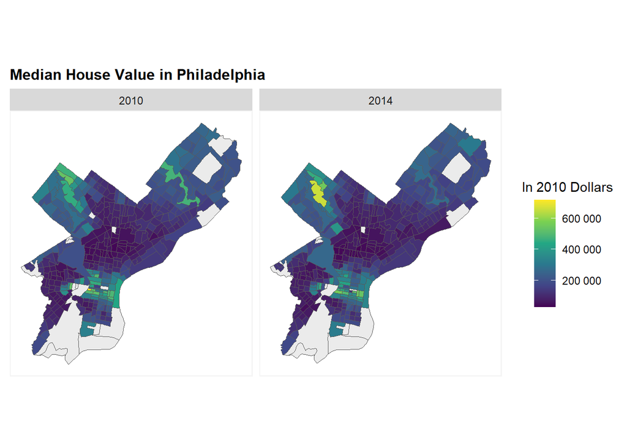

```r
ggplot(Philly_combined, aes(fill = Med_House_Val)) +
  geom_sf() +
  scale_fill_viridis_c(labels = scales::label_number(),
                       name = "Median House Value",
                       na.value = "#ebebeb",
                       guide = guide_colorbar(title.position = "top", title.hjust = 0.5,
                                              title = "In 2010 Dollars")) +
  labs(title = "Median House Value in Philadelphia",
       fill = NULL) +  # Remove the fill legend title
  theme(axis.text.x = element_blank(),
        axis.text.y = element_blank(),
        axis.ticks = element_blank(),
        axis.title.x = element_blank(),
        axis.title.y = element_blank(),
        plot.subtitle = element_blank(),
        plot.title = element_text(size = 12, face = "bold"),
        panel.background = element_blank(),
        panel.border = element_rect(colour = "#F5f5f5", fill = NA, linewidth = 0.8)) +
  facet_wrap(~year, nrow = 1)
```

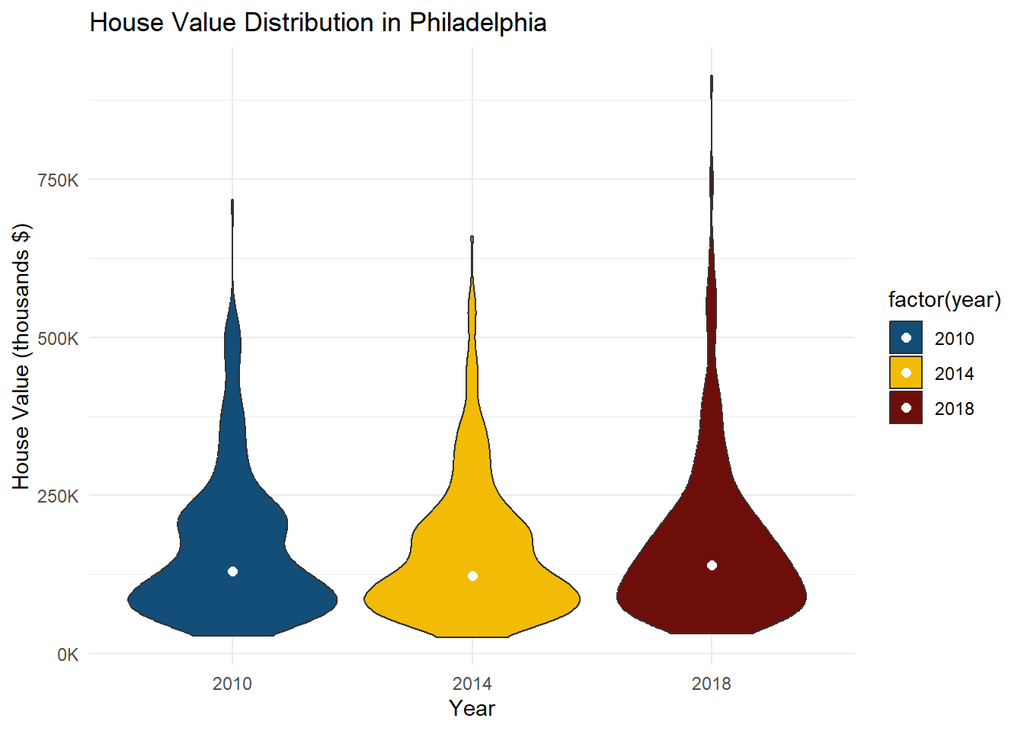

```r
Philly_housingprice <- rbind(transform(Philly2010, year = 2010),
                         transform(Philly2014, year = 2014),
                         transform(Philly2018, year = 2018))

ggplot(Philly_housingprice, aes(x = factor(year), y = Med_House_Val, fill = factor(year))) +
  geom_violin() +
  scale_fill_manual(values = palette3) +
  labs(x = "Year", y = "House Value (thousands $)", title = "House Value Distribution in Philadelphia") +
  scale_y_continuous(labels = function(x) paste0(x/1000, "K")) +
  theme_minimal() +
  stat_summary(fun.y = median, geom = "point", size = 2, color = "white")
```

## White Population Percentage

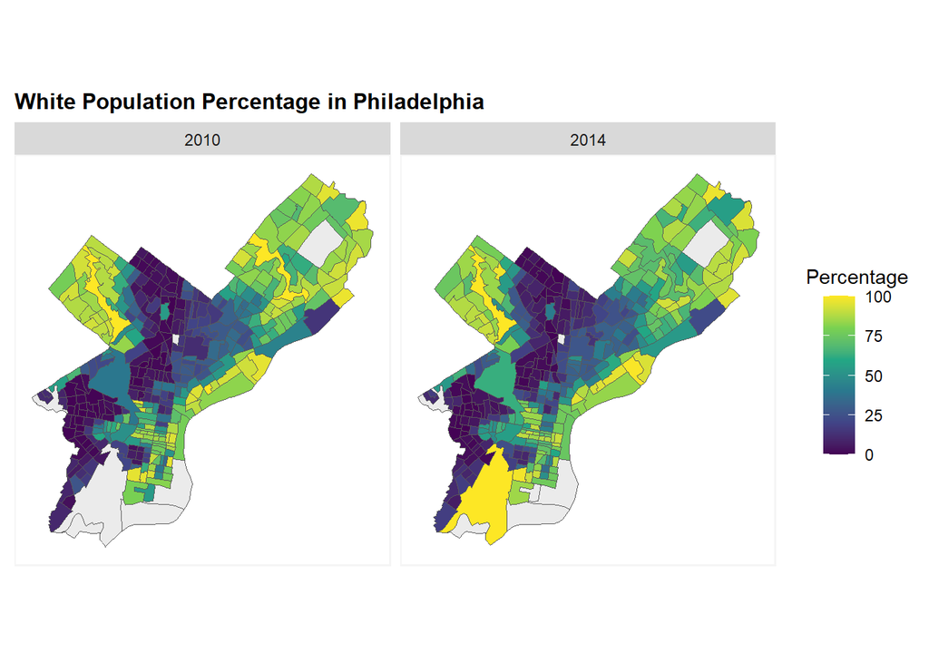

```r
ggplot(Philly_combined, aes(fill = White_Share)) +
  geom_sf() +
  scale_fill_viridis_c(labels = scales::label_number(),
                       name = "White_Pop_Pct",
                       na.value = "#ebebeb",
                       guide = guide_colorbar(title.position = "top", title.hjust = 0.5,
                                              title = "Percentage")) +
  labs(title = "White Population Percentage in Philadelphia",
       fill = NULL) +  # Remove the fill legend title
  theme(axis.text.x = element_blank(),
        axis.text.y = element_blank(),
        axis.ticks = element_blank(),
        axis.title.x = element_blank(),
        axis.title.y = element_blank(),
        plot.subtitle = element_text(size = 9, face = "italic"),
        plot.title = element_text(size = 12, face = "bold"),
        panel.background = element_blank(),
        panel.border = element_rect(colour = "#F5f5f5", fill = NA, linewidth = 0.8)) +
  facet_wrap(~year, nrow = 1)
```

## Philadelphia 2010-2014 Changes

```r
Philly10to14 <- Philly_combined %>%
  group_by(GEOID, Tract) %>%
  summarise(
    Total_Pop_change = Total_Pop[year == 2014] - Total_Pop[year == 2010],
    Total_White_Pop_change = White_Pop[year == 2014] - White_Pop[year == 2010],
    BachelorsDegree_change = BachelorsDegree[year == 2014] - BachelorsDegree[year == 2010],
    Med_HH_Inc_change = Med_HH_Inc[year == 2014] - Med_HH_Inc[year == 2010],
    Med_House_Val_change = Med_House_Val[year == 2014] - Med_House_Val[year == 2010],
    Med_Rent_change = Med_Rent[year == 2014] - Med_Rent[year == 2010],
    White_Share_Change = White_Share[year == 2014] - White_Share[year == 2010]
  )
Philly2010NoGeo <- Philly2010 %>%
  st_drop_geometry()

Philly10to14 <- left_join(Philly10to14, Philly2010NoGeo, by = "Tract") %>%
  dplyr::select(-GEOID.y)

Philly10to14 <- Philly10to14 %>%
  mutate(
    Pop_PctChange = (Total_Pop_change/Total_Pop)*100,
    White_Pop_PctChange = (Total_White_Pop_change/White_Pop)*100,
    BachelorsDegree_PctChange = (BachelorsDegree_change/BachelorsDegree)*100,
    Med_HH_Inc_PctChange = (Med_HH_Inc_change/Med_HH_Inc)*100,
    Med_House_Val_PctChange = (Med_House_Val_change/Med_House_Val)*100,
    Med_Rent_PctChange = (Med_Rent_change/Med_Rent)*100
  ) %>%
  dplyr::select(-Total_Pop,
         -White_Pop,
         -BachelorsDegree,
         -Med_HH_Inc,
         -Med_House_Val,
         -Med_Rent_change,
         -White_Share)
```

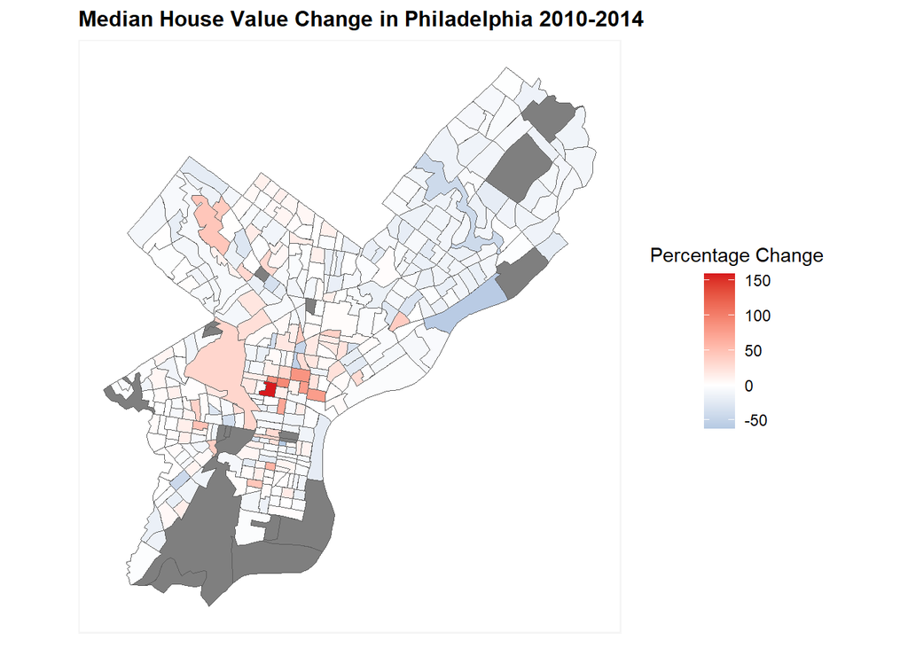

```r
ggplot(Philly10to14, aes(fill = Med_House_Val_PctChange)) +
  geom_sf() +
  scale_fill_gradient2(low = "#2C7BB6", mid = "white", high = "#D7191C",
                       midpoint = 0,
                       labels = scales::label_number(),
                       name = "Median House Value Change",
                       guide = guide_colorbar(title.position = "top", title.hjust = 0.5,
                                              title = "Percentage Change")) +
  labs(title = "Median House Value Change in Philadelphia 2010-2014",
       fill = NULL) +  # Remove the fill legend title
  theme(axis.text.x = element_blank(),
        axis.text.y = element_blank(),
        axis.ticks = element_blank(),
        axis.title.x = element_blank(),
        axis.title.y = element_blank(),
        plot.subtitle = element_text(size = 9, face = "italic"),
        plot.title = element_text(size = 12, face = "bold"),
        panel.background = element_blank(),
        panel.border = element_rect(colour = "#F5f5f5", fill = NA, linewidth = 0.8))
```

Discuss results, when compared with median house values and white population in 2010 and 2014 areas with extremely cheap houses and very low percentage of white residents saw the greatest *percentage* increase in house values–largely north-central Philadelphia in areas close to existing “creative class” Center City-adjacent areas, such as Fairmount, with some affects of the widening sphere of influence of Temple U as well. (partially explained by law of diminishing marginal returns)

# Data Wrangling

Spatial autocorrelation of Census tracts, collinear variables among the independent variables used to measure gentrification need to be explored before model creation for better evaluation (model evaluating gentrification by using median home values).

## Spatial Lag

Spatial lag is a concept used in spatial analysis and spatial econometrics to account for spatial dependencies in data. It refers to a new variable that represents the average value of a particular variable for neighboring spatial units, in this case neighboring Census tracts. In other words, the spatial lag of a variable, such as home values, for a specific Census tract is the average value of that variable for neighboring tracts. This allows one to capture the spatial autocorrelation or spatial dependence present in the data. Here, this is important due to the theory of [endogenous gentrification,](http://www.nber.org/papers/w16237) which states that neighborhoods close to high-amenity, expensive ones will gentrify earlier due to this proximity than those further away from existing centers of wealth and investment.

Spatial lag is often used in regression analysis to account for spatial dependencies among observations. Including the spatial lag of a variable as an additional predictor in a regression model helps to control for spatial autocorrelation and can improve the model’s accuracy and interpretability, especially when the dependent variable exhibits spatial patterns.

The following deals with median house value. In 2010’s data, there are only 366 observations as opposed to 384 observations. A few tracts do not have median home values. This will appear as “Philly2010Lag”; 2014 data will be joined as “Philly2010Lag14”.

```r
# Replace non-finite values with NA
Philly2010$Med_House_Val[!is.finite(Philly2010$Med_House_Val)] <- NA #Rows without values are omitted here

# Remove NA rows for calculating the spatial lag
Philly2010Lag <- na.omit(Philly2010)

# Create neighbor list weights
Philly2010nb <- poly2nb(Philly2010Lag, queen = TRUE)
Philly2010weights <- nb2listw(Philly2010nb, style = "W")

# Calculate the spatial lag
Philly2010Lag$NborHouseVal <- lag.listw(Philly2010weights, Philly2010Lag$Med_House_Val)

# Now to see the correlation between 2010 Spatial Lag values (average neighbor tracts house value) and 2014 House Prices
Philly2014NoGeo <- Philly2014 %>%
  st_drop_geometry()

Philly2010NoGeo <- Philly2010Lag %>%
  st_drop_geometry()

Philly2010Lag14 <- merge(Philly2010NoGeo, Philly2014NoGeo, by = "GEOID", suffixes = c("_2010", "_2014"))

# Calculate the correlation
correlation <- cor(Philly2010Lag14$NborHouseVal, Philly2010Lag14$Med_House_Val_2014)

#Moran's I Coefficient
Lag1 <- lm(Philly2010Lag14$NborHouseVal ~ Philly2010Lag14$Med_House_Val_2014)
coef(Lag1)[2]
```

```
## Philly2010Lag14$Med_House_Val_2014
##                          0.7419846
```

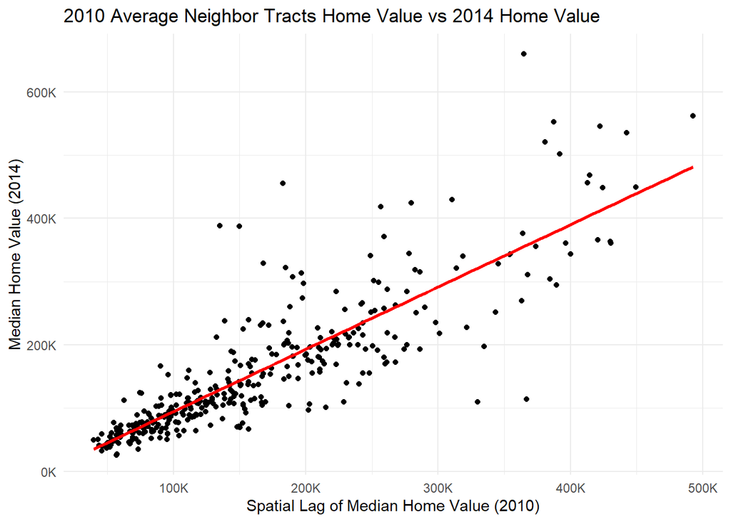

```r
# Create a scatter plot
ggplot(Philly2010Lag14, aes(x = NborHouseVal, y = Med_House_Val_2014)) +
  geom_point() +
  geom_smooth(method = "lm", se = FALSE, color = "red") +  # Add linear regression line
  labs(title = "2010 Average Neighbor Tracts Home Value vs 2014 Home Value",
       x = "Spatial Lag of Median Home Value (2010)",
       y = "Median Home Value (2014)") +
  scale_x_continuous(labels = function(x) paste0(x/1000, "K")) +  # Format x-axis labels as numeric in thousands
  scale_y_continuous(labels = function(x) paste0(x/1000, "K")) +  # Format y-axis labels as numeric in thousands
  theme_minimal()
```

The Moran’s I coefficient is 0.74. The positive (upward) slope suggests that as the house value of a said polygon increases, so does those of its neighboring polygons.

## Moran’s I

(The following is taken from Fichman & Co’s page) There are three local spatial patterns of home prices that we are interested in: clustering of high prices; clustering of low prices; and spatial randomness of prices.

Local clustering of high and low prices suggests that housing market agents agree on equilibrium prices in a given neighborhood. Local randomness, we argue, is indicative of a changing neighborhood – one that is out of equilibrium.

In a changing neighborhood, buyers and sellers are unable to predict the value of future amenities. Our theory argues that when this uncertainty is capitalized into prices, the result is a heterogeneous pattern of prices across space. Capturing this spatial trend is crucial for forecasting neighborhood change.

Homogeneous prices in the are indicative of an area in equilibrium where all housing market agents agree on future expectations. Heterogeneous prices is more indicative of a neighborhood in flux – one where housing market agents are capitalizing an uncertain future into prices.

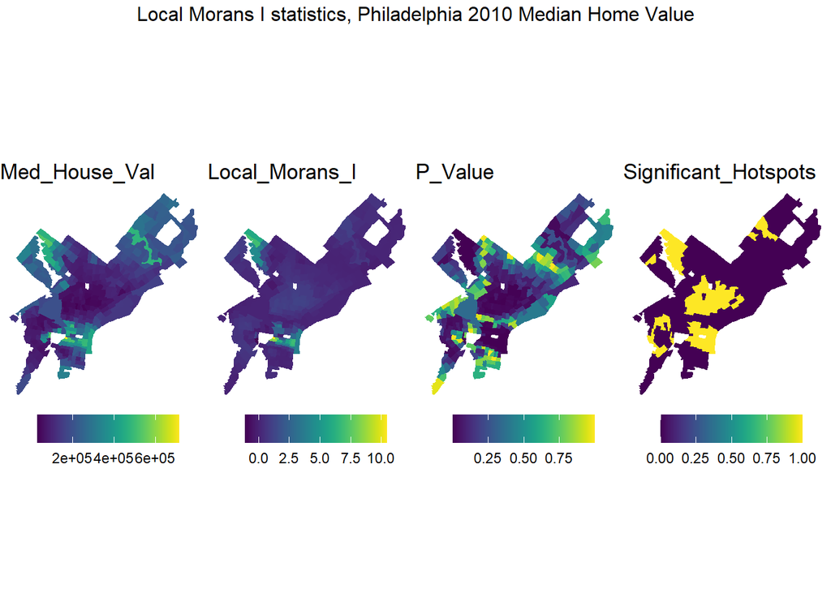

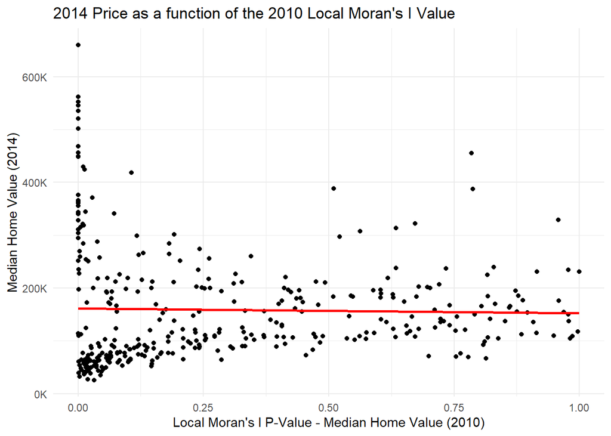

## Correlation Matrix

```
## Correlation computed with
## • Method: 'pearson'
## • Missing treated using: 'pairwise.complete.obs'
```

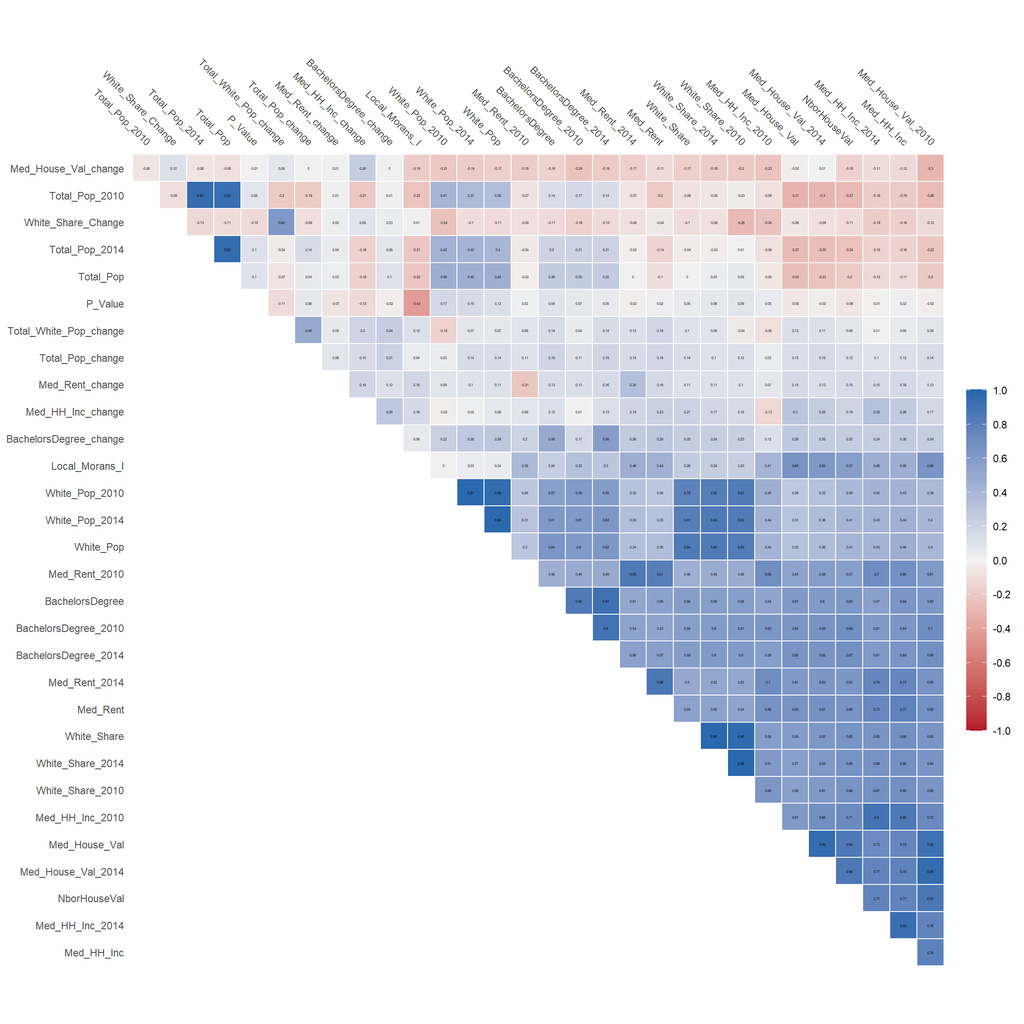

```r
Philly1014 <- Philly2010Lag14 %>%
  mutate(
    Total_Pop_change = Total_Pop_2014 - Total_Pop_2010,
    Total_White_Pop_change = White_Pop_2014 - White_Pop_2010,
    BachelorsDegree_change = BachelorsDegree_2014 - BachelorsDegree_2010,
    Med_HH_Inc_change = Med_HH_Inc_2014 - Med_HH_Inc_2010,
    Med_House_Val_change = Med_House_Val_2014 - Med_House_Val_2010,
    Med_Rent_change = Med_Rent_2014 - Med_Rent_2010,
    White_Share_Change = White_Share_2014 - White_Share_2010)%>%
  na.omit()


Philly2018_df <- as.data.frame(Philly2018)
dat18 <- merge(Philly1014, Philly2018_df, by = "GEOID", all.x = FALSE, all.y=FALSE, sort
= FALSE)

# correlation matrix
dat18.Numeric <- dat18 %>%
  st_drop_geometry() %>%
  select_if(is.numeric) %>%
  na.omit()
dat18.Numeric <- dat18 %>% select_if(is.numeric)
# Calculate correlation matrix
correlation_matrix <- cor(dat18.Numeric)

# Create correlation plot
dat18.Numeric %>%
  correlate() %>%
  autoplot() +
  geom_text(aes(label = round(r,digits=2)),size = 1)
```

# Model Evaluation

```
##           NborHouseVal       Total_Pop_change Total_White_Pop_change
##               3.052014               1.985165               3.430486
## BachelorsDegree_change      Med_HH_Inc_change   Med_House_Val_change
##               1.489970               1.315176               1.127897
##        Med_Rent_change     White_Share_Change              Total_Pop
##               1.057262               2.639109               1.458508
##        BachelorsDegree             Med_HH_Inc               Med_Rent
##               3.005126               4.031154               2.700259
```

```
## [1] 9019.889
```

```
## [1] 9074.372
```

```
##
## ==================================================
##                            Dependent variable:
##                        ---------------------------
##                               Med_House_Val
## --------------------------------------------------
## NborHouseVal                     0.104**
##                                  (0.045)
##
## Med_House_Val_2014              0.996***
##                                  (0.041)
##
## Total_White_Pop_change           -0.393
##                                  (5.852)
##
## BachelorsDegree_change            1.706
##                                 (17.648)
##
## Med_HH_Inc_change               1.056***
##                                  (0.259)
##
## Med_House_Val_change            -0.123**
##                                  (0.062)
##
## Med_Rent_change                  19.894
##                                 (16.174)
##
## Total_Pop                       -4.254***
##                                  (1.434)
##
## BachelorsDegree                 29.943***
##                                  (9.494)
##
## Med_HH_Inc                      -0.443**
##                                  (0.185)
##
## Med_Rent                          7.649
##                                 (12.283)
##
## Constant                       10,373.630
##                               (10,409.500)
##
## --------------------------------------------------
## Observations                       362
## R2                                0.918
## Adjusted R2                       0.916
## Residual Std. Error       36,968.510 (df = 350)
## F Statistic             357.131*** (df = 11; 350)
## ==================================================
## Note:                  *p<0.1; **p<0.05; ***p<0.01
```

```
##           NborHouseVal     Med_House_Val_2014 Total_White_Pop_change
##               4.663146               5.127385               1.147932
## BachelorsDegree_change      Med_HH_Inc_change   Med_House_Val_change
##               1.489546               1.311173               1.230228
##        Med_Rent_change              Total_Pop        BachelorsDegree
##               1.052775               1.509523               3.091400
##             Med_HH_Inc               Med_Rent
##               4.257867               2.719984
```

```
## [1] 8656.011
```

```
## [1] 8706.602
```

```
## Analysis of Variance Table
##
## Model 1: Med_House_Val ~ (Total_Pop_2010 + White_Pop_2010 + BachelorsDegree_2010 +
##     Med_HH_Inc_2010 + Med_House_Val_2010 + Med_Rent_2010 + White_Share_2010 +
##     NborHouseVal + Total_Pop_2014 + White_Pop_2014 + BachelorsDegree_2014 +
##     Med_HH_Inc_2014 + Med_House_Val_2014 + Med_Rent_2014 + White_Share_2014 +
##     Local_Morans_I + P_Value + Total_Pop_change + Total_White_Pop_change +
##     BachelorsDegree_change + Med_HH_Inc_change + Med_House_Val_change +
##     Med_Rent_change + White_Share_Change + Total_Pop + White_Pop +
##     BachelorsDegree + Med_HH_Inc + Med_Rent + White_Share) -
##     Total_Pop_2010 - White_Pop_2010 - BachelorsDegree_2010 -
##     Med_HH_Inc_2010 - Med_House_Val_2010 - Med_Rent_2010 - White_Share_2010 -
##     Total_Pop_2014 - White_Pop_2014 - BachelorsDegree_2014 -
##     Med_HH_Inc_2014 - Med_Rent_2014 - White_Share_2014 - Local_Morans_I -
##     P_Value - White_Share - White_Pop - Med_House_Val_2014
## Model 2: Med_House_Val ~ (Total_Pop_2010 + White_Pop_2010 + BachelorsDegree_2010 +
##     Med_HH_Inc_2010 + Med_House_Val_2010 + Med_Rent_2010 + White_Share_2010 +
##     NborHouseVal + Total_Pop_2014 + White_Pop_2014 + BachelorsDegree_2014 +
##     Med_HH_Inc_2014 + Med_House_Val_2014 + Med_Rent_2014 + White_Share_2014 +
##     Local_Morans_I + P_Value + Total_Pop_change + Total_White_Pop_change +
##     BachelorsDegree_change + Med_HH_Inc_change + Med_House_Val_change +
##     Med_Rent_change + White_Share_Change + Total_Pop + White_Pop +
##     BachelorsDegree + Med_HH_Inc + Med_Rent + White_Share) -
##     Total_Pop_2010 - White_Pop_2010 - BachelorsDegree_2010 -
##     Med_HH_Inc_2010 - Med_House_Val_2010 - Med_Rent_2010 - White_Share_2010 -
##     Total_Pop_2014 - White_Pop_2014 - BachelorsDegree_2014 -
##     Med_HH_Inc_2014 - Med_Rent_2014 - White_Share_2014 - Local_Morans_I -
##     P_Value - White_Share - White_Pop - White_Share_Change -
##     Total_Pop_change
##   Res.Df           RSS Df    Sum of Sq F Pr(>F)
## 1    349 1299808775441
## 2    350  478334770644 -1 821474004797
```

## K-fold Cross Validation

```r
set.seed(123)
dat18.Numeric <- na.omit(dat18.Numeric)

#Define the control parameters for k-fold cross-validation
control <- trainControl(method = "cv",
                        number = 10,
                        verboseIter = TRUE,
                        returnData = FALSE,
                        savePredictions = TRUE,
                        classProbs = FALSE,
                        summaryFunction = defaultSummary)

# Train the linear regression model using k-fold cross-validation
lm_cv <- train(Med_House_Val ~ . - Total_Pop_2010 - White_Pop_2010 - BachelorsDegree_2010 -
                           Med_HH_Inc_2010 - Med_House_Val_2010 - Med_Rent_2010 - White_Share_2010 -
                           Total_Pop_2014 - White_Pop_2014 - BachelorsDegree_2014 - Med_HH_Inc_2014 -
                           Med_Rent_2014 - White_Share_2014 - Local_Morans_I - P_Value -White_Share -White_Pop -White_Share_Change -Total_Pop_change,
               data = dat18.Numeric,
               method = "lm",
               trControl = control)
print(lm_cv)
```

```
## Linear Regression
##
## No pre-processing
## Resampling: Cross-Validated (10 fold)
## Summary of sample sizes: 326, 325, 326, 326, 326, 325, ...
## Resampling results:
##
##   RMSE      Rsquared   MAE
##   37148.29  0.9297831  23762.12
##
## Tuning parameter 'intercept' was held constant at a value of TRUE
```

## Mean Absolute Error

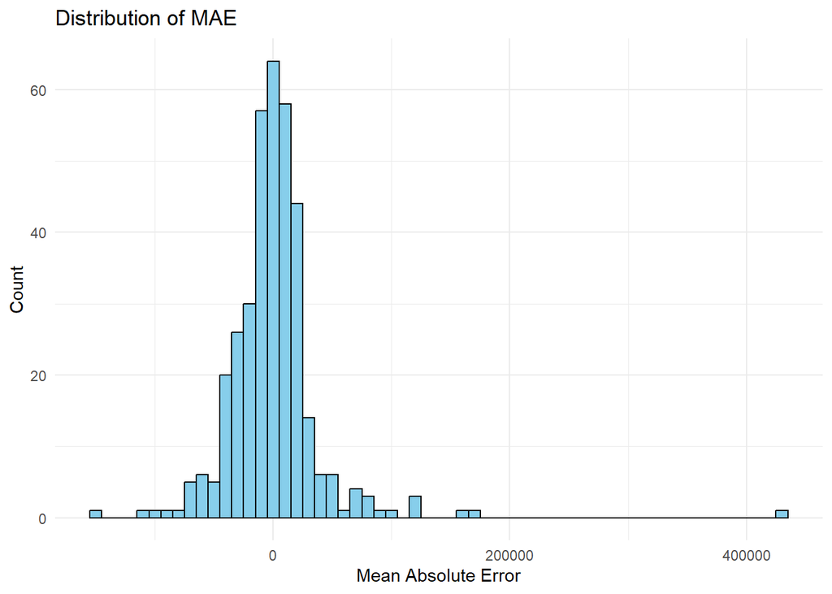

```r
# Extract the Out-of-Fold (OOF) predictions from the cross-validated model
oof_predictions <- lm_cv$pred$pred
oof_actual <- lm_cv$pred$obs
oof_errors <- oof_actual - oof_predictions

# Create a data frame for the OOF errors
oof_data <- data.frame(OOF_Error = oof_errors)

# Plot the histogram of OOF errors
ggplot(oof_data, aes(x = OOF_Error)) +
  geom_histogram(binwidth = 10000, fill = "skyblue", color = "black") +
  labs(x = "Mean Absolute Error", y = "Count", title = "Distribution of MAE") +
  theme_minimal()
```

## Goodness of Fit Metrics

talking about the results of regression text from Fichman paper: The “MAPE” or mean absolute percentage error, is the absolute value of the average error (the difference between observed and predicted prices by tract) represented as a percentage which allows for a more consistent way to describe model error across cities.

If the model is inconsistent across each permutation, it may be that the goodness of fit is driven solely by individual observations drawn at random. This latter outcome might indicate overfitting. Thus, this metric collects R^2 statistics for each random permutation and then uses standard deviation to assess whether the variation in goodness of fit across each permutation is small (ie. generalizability) or a large (ie. overfitting).

```r
# MAPE
# Obtain the predicted values from the model:
predicted <- predict(reg2, newdata = dat18.Numeric)

# Calculate the absolute percentage error for each observation:
absolute_error <- abs((dat18.Numeric$Med_House_Val - predicted) / dat18.Numeric$Med_House_Val) * 100

# Mean Absolute Percentage Error (MAPE)
mape <- mean(absolute_error, na.rm = TRUE)

# Residual Standard Error (RSE)
rse <- sqrt(sum(reg2$residuals^2) / reg2$df.residual)

# Adjusted R-squared
adj_r_squared <- summary(reg2)$adj.r.squared

# Create a data frame for the table
results <- data.frame(Model = "reg2",
                       `Residual Standard Error (RSE)` = rse,
                       `Adjusted R-squared` = adj_r_squared,
                       MAPE = mape)

# Print the table
print(results)
```

```
##   Model Residual.Standard.Error..RSE. Adjusted.R.squared     MAPE
## 1  reg2                      36968.51          0.9156234 13.83355
```

## Mean Absolute Percentage Error

(x-axis (Observation): This represents the individual observations or data points in your dataset. Each point on the x-axis corresponds to a specific data point.

y-axis (MAPE): This represents the Mean Absolute Percentage Error (MAPE) values. MAPE is a measure of prediction accuracy, typically used for forecasting models. It calculates the percentage difference between actual and predicted values.

geom_line(): This function adds a line plot to the graph, connecting the MAPE values for each observation. This line gives an overview of how MAPE changes across different observations.

geom_hline(): This function adds a horizontal dashed line at a specific y-value, which is represented by mape. This line is usually used as a reference, such as a threshold or target MAPE value.)- for understanding

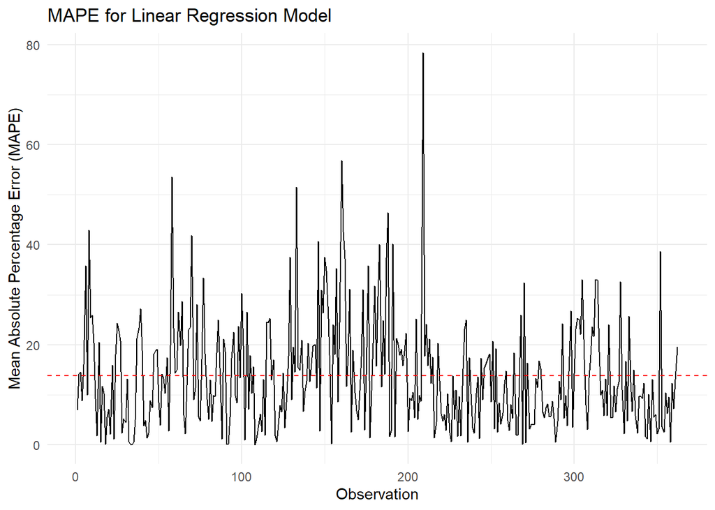

```r
# Create a data frame with MAPE values
mape_data <- data.frame(Observation = 1:length(absolute_error), MAPE = absolute_error)

# Create plot for MAPE
ggplot(mape_data, aes(x = Observation, y = MAPE)) +
  geom_line() +
  geom_hline(yintercept = mape, linetype = "dashed", color = "red") +
  labs(x = "Observation", y = "Mean Absolute Percentage Error (MAPE)", title = "MAPE for Linear Regression Model") +
  theme_minimal()
```

## Predicted vs Observed plot

Predicted prices as a function of observed prices for all tracts: If predictions were perfect, we would expect the below scatterplots to look like straight lines. most of the points are near the line, except for one, which is a Census tract comprising much of Rittenhouse Square- the model predicts prices poorly for it.

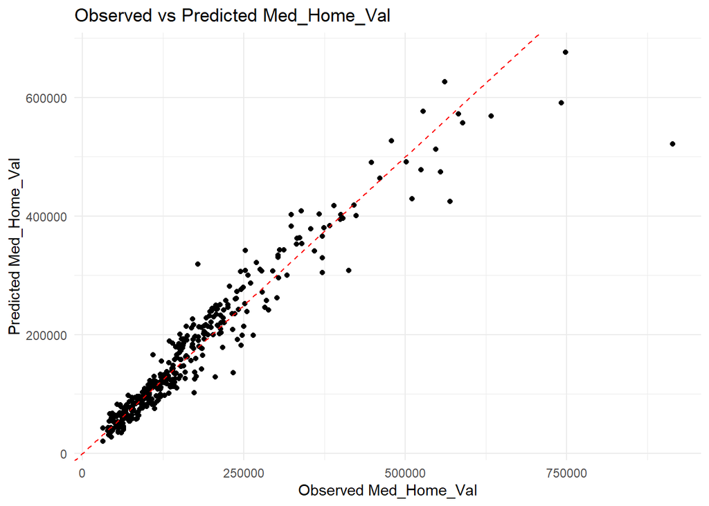

```r
plot_data <- data.frame(Observed = dat18.Numeric$Med_House_Val, Predicted = predicted)

# scatter plot
ggplot(plot_data, aes(x = Observed, y = Predicted)) +
  geom_point() +
  geom_abline(intercept = 0, slope = 1, linetype = "dashed", color = "red") +
  labs(x = "Observed Med_Home_Val", y = "Predicted Med_Home_Val", title = "Observed vs Predicted Med_Home_Val") +
  theme_minimal()
```

# Data Validation: Baltimore

## Data Collection and Wrangling

```r
Balti_combined <- rbind(transform(Balti2010, year = 2010),
                         transform(Balti2014, year = 2014),
                         transform(Balti2018, year = 2018))

Balti_combined <- Balti_combined %>%
  mutate(Total_Pop_2018       = ifelse(year == 2018 & !is.na(Total_Pop), Total_Pop, NA),
    White_Pop_2018       = ifelse(year == 2018 & !is.na(White_Pop), White_Pop, NA),
    BachelorsDegree_2018 = ifelse(year == 2018 & !is.na(BachelorsDegree), BachelorsDegree, NA),
    Med_HH_Inc_2018      = ifelse(year == 2018 & !is.na(Med_HH_Inc), Med_HH_Inc, NA),
    Med_House_Val_2018   = ifelse(year == 2018 & !is.na(Med_House_Val), Med_House_Val, NA),
    Med_Rent_2018        = ifelse(year == 2018 & !is.na(Med_Rent), Med_Rent, NA),
    White_Share_2018     = ifelse(year == 2018 & !is.na(White_Share), White_Share, NA))

Balti_combined <- Balti_combined %>%
  group_by(GEOID, Tract) %>%
  mutate(
    Total_Pop_change = Total_Pop[year == 2014] - Total_Pop[year == 2010],
    Total_White_Pop_change = White_Pop[year == 2014] - White_Pop[year == 2010],
    BachelorsDegree_change = BachelorsDegree[year == 2014] - BachelorsDegree[year == 2010],
    Med_HH_Inc_change = Med_HH_Inc[year == 2014] - Med_HH_Inc[year == 2010],
    Med_House_Val_change = Med_House_Val[year == 2014] - Med_House_Val[year == 2010],
    Med_Rent_change = Med_Rent[year == 2014] - Med_Rent[year == 2010],
    White_Share_Change = White_Share[year == 2014] - White_Share[year == 2010],
    Med_House_Val14 = Med_House_Val[year == 2014],
    Med_House_Val10 = Med_House_Val[year == 2010])

Balti_combined <- Balti_combined %>%
  select(-Total_Pop, -White_Pop, -BachelorsDegree, -Med_HH_Inc,-Med_Rent, -White_Share, -Med_House_Val)


# Convert Balti_combined to a data frame if it's not already
if (!is.data.frame(Balti_combined)) {
  Balti_combined <- as.data.frame(Balti_combined)
}

# Remove rows where Total_Pop_2018 is empty (contains NA values)
Balti_combined <- Balti_combined[complete.cases(Balti_combined$Total_Pop_2018), ]

Balti_combined <- Balti_combined %>% na.omit()

# NborHouseVal
Balti_combinednb <- poly2nb(Balti_combined, queen = TRUE)
Balti_combinedweights <- nb2listw(Balti_combinednb, style = "W")

# Calculate the spatial lag
Balti_combined$NborHouseVal <- lag.listw(Balti_combinedweights, Balti_combined$Med_House_Val10)
```

## Regression

- this is a simplified version of the Philadelphia model, which doesn’t include some local-level variables but does include a spatial lag variable (which would need to be made for each city before model application)

```r
Balti_combinedNoGeo <- Balti_combined %>%
  st_drop_geometry()
reg3 <- lm(Med_House_Val_2018 ~ . -GEOID -Tract -year -Med_House_Val10 -White_Pop_2018 -White_Share_Change -Total_Pop_change, data = Balti_combinedNoGeo)
summary(reg3)
```

```
##
## Call:
## lm(formula = Med_House_Val_2018 ~ . - GEOID - Tract - year -
##     Med_House_Val10 - White_Pop_2018 - White_Share_Change - Total_Pop_change,
##     data = Balti_combinedNoGeo)
##
## Residuals:
##    Min     1Q Median     3Q    Max
## -63602 -11005  -2624   8633  65648
##
## Coefficients:
##                            Estimate   Std. Error t value             Pr(>|t|)
## (Intercept)            -16654.77410   9160.61207  -1.818               0.0707
## Total_Pop_2018             -1.15450      1.49400  -0.773               0.4407
## BachelorsDegree_2018        8.65144      9.74782   0.888               0.3760
## Med_HH_Inc_2018             0.43342      0.14984   2.893               0.0043
## Med_Rent_2018               1.20391      8.95164   0.134               0.8932
## White_Share_2018          127.82413     87.51811   1.461               0.1459
## Total_White_Pop_change      8.41217      7.81962   1.076               0.2835
## BachelorsDegree_change      8.10202     14.58250   0.556               0.5792
## Med_HH_Inc_change          -0.22757      0.22821  -0.997               0.3200
## Med_House_Val_change       -0.29129      0.05208  -5.593         0.0000000827
## Med_Rent_change             6.53944      9.08962   0.719               0.4728
## Med_House_Val14             0.78275      0.03844  20.361 < 0.0000000000000002
## NborHouseVal                0.09744      0.04176   2.333               0.0207
##
## (Intercept)            .
## Total_Pop_2018
## BachelorsDegree_2018
## Med_HH_Inc_2018        **
## Med_Rent_2018
## White_Share_2018
## Total_White_Pop_change
## BachelorsDegree_change
## Med_HH_Inc_change
## Med_House_Val_change   ***
## Med_Rent_change
## Med_House_Val14        ***
## NborHouseVal           *
## ---
## Signif. codes:  0 '***' 0.001 '**' 0.01 '*' 0.05 '.' 0.1 ' ' 1
##
## Residual standard error: 20590 on 178 degrees of freedom
## Multiple R-squared:  0.9466, Adjusted R-squared:  0.943
## F-statistic: 263.2 on 12 and 178 DF,  p-value: < 0.00000000000000022
```

```r
stargazer(reg2, type = "text")
```

```
##
## ==================================================
##                            Dependent variable:
##                        ---------------------------
##                               Med_House_Val
## --------------------------------------------------
## NborHouseVal                     0.104**
##                                  (0.045)
##
## Med_House_Val_2014              0.996***
##                                  (0.041)
##
## Total_White_Pop_change           -0.393
##                                  (5.852)
##
## BachelorsDegree_change            1.706
##                                 (17.648)
##
## Med_HH_Inc_change               1.056***
##                                  (0.259)
##
## Med_House_Val_change            -0.123**
##                                  (0.062)
##
## Med_Rent_change                  19.894
##                                 (16.174)
##
## Total_Pop                       -4.254***
##                                  (1.434)
##
## BachelorsDegree                 29.943***
##                                  (9.494)
##
## Med_HH_Inc                      -0.443**
##                                  (0.185)
##
## Med_Rent                          7.649
##                                 (12.283)
##
## Constant                       10,373.630
##                               (10,409.500)
##
## --------------------------------------------------
## Observations                       362
## R2                                0.918
## Adjusted R2                       0.916
## Residual Std. Error       36,968.510 (df = 350)
## F Statistic             357.131*** (df = 11; 350)
## ==================================================
## Note:                  *p<0.1; **p<0.05; ***p<0.01
```

```r
vif(reg2)
```

```
##           NborHouseVal     Med_House_Val_2014 Total_White_Pop_change
##               4.663146               5.127385               1.147932
## BachelorsDegree_change      Med_HH_Inc_change   Med_House_Val_change
##               1.489546               1.311173               1.230228
##        Med_Rent_change              Total_Pop        BachelorsDegree
##               1.052775               1.509523               3.091400
##             Med_HH_Inc               Med_Rent
##               4.257867               2.719984
```

## Evaluation

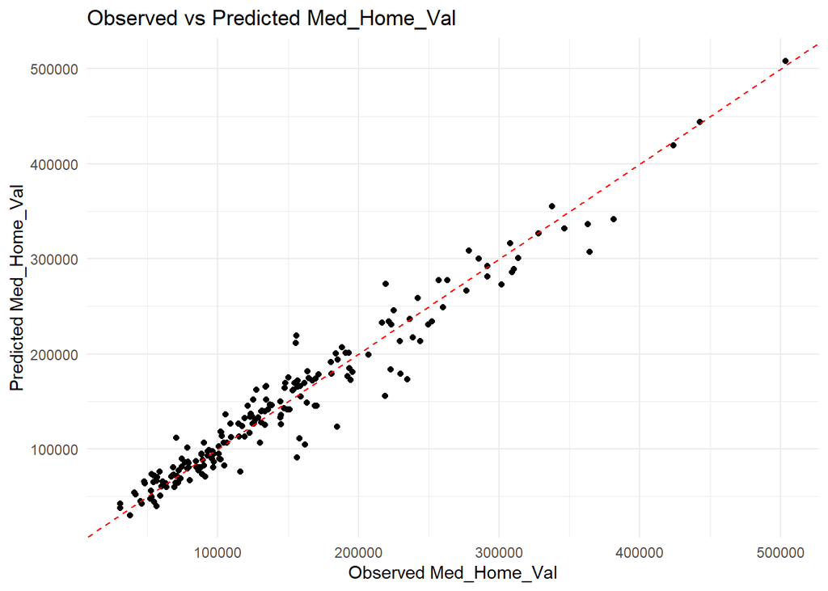

```r
# Obtain the predicted values from the model:
Balti_combined$predicted <- predict(reg3, newdata = Balti_combinedNoGeo)

plot_data <- data.frame(Observed = Balti_combined$Med_House_Val_2018, Predicted = Balti_combined$predicted)

# Create scatter plot
ggplot(plot_data, aes(x = Observed, y = Predicted)) +
  geom_point() +  # Add points for observed vs predicted
  geom_abline(intercept = 0, slope = 1, linetype = "dashed", color = "red") +  # Add diagonal line for perfect prediction
  labs(x = "Observed Med_Home_Val", y = "Predicted Med_Home_Val", title = "Observed vs Predicted Med_Home_Val") +
  theme_minimal()  # Apply minimal theme
```

## Map

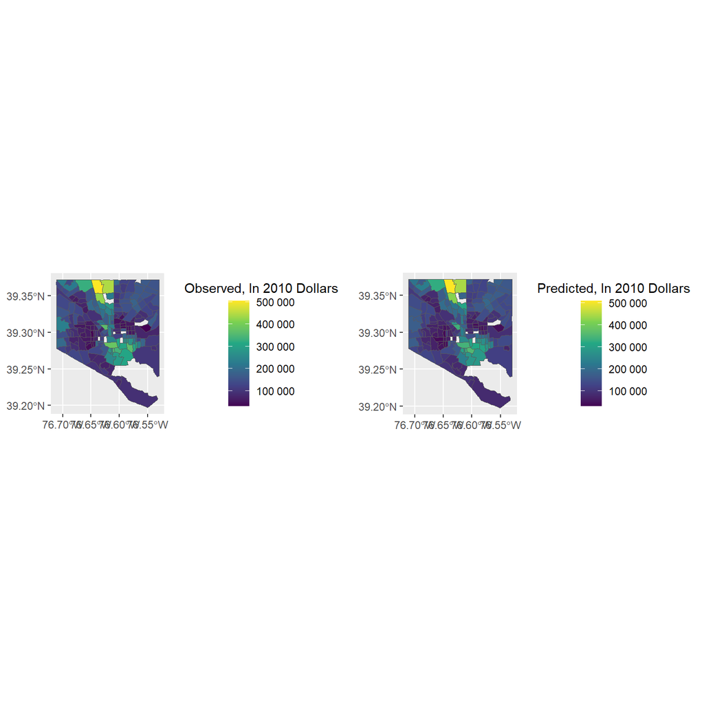

```r
a1 <- ggplot()+
  geom_sf(data = Balti_combined, aes(fill = Med_House_Val_2018))+
  scale_fill_viridis_c(labels = scales::label_number(),
                       name = "Median House Value",
                       na.value = "#ebebeb",
                       guide = guide_colorbar(title.position = "top", title.hjust = 0.5,
                                              title = "Observed, In 2010 Dollars"))

a2 <- ggplot()+
  geom_sf(data = Balti_combined, aes(fill = predicted))+
  scale_fill_viridis_c(labels = scales::label_number(),
                       name = "Median House Value",
                       na.value = "#ebebeb",
                       guide = guide_colorbar(title.position = "top", title.hjust = 0.5,
                                              title = "Predicted, In 2010 Dollars"))

grid.arrange(a1,a2, ncol =2)
```

# Conclusion

Fichman et al.: While standardizing tract geographies over time is certainly convenient, it does not account for the ecological fallacy nor deal with the fact that tracts rarely comprise actual real estate submarkets.